# Lab #2: Probability, Distributions, and Statistical Questions

### Problem 1

In lecture and homework we explored how the convolution can be used to calculate the probability of a sum or average. For this problem we are going to imagine that we are looking for gamma-ray sources (e.g. with the Fermi telescope). In this kind of telescope there is a background of cosmic-rays (electrons and protons, mostly) that provides a discrete noise term across the sky that precisely follows a Poisson distribution. To detect a gamma-ray source, you need to ask what is the probability that the cosmic-ray background would have given you a measurement as signal-like or more than the signal that you received.

To set up the problem, assume in 1 day the average cosmic-ray background is some number X (pick someting btwn 0.5 and 10, with different values for you and your lab partner); and the average number of gamma-rays emitted by your hypothetical source is Y (pick something larger than X).

A) Show how the probability distribution of the background changes as you integrate (sum) for more days.

B) Show that after 5 days, the summed probability distribution is still a Poisson distribution. Explain why this makes sense from a mathematical and conceptual point of view.

C) Show how the probability distribution evolves as you average days. Calculate for many different ranges of days, and explore the shape of the distribution as the number of days becomes larger. Discuss this in relation to both B) and the central limit theoem.

D) Pick some number of days N, and assume you saw Y*N gamma rays from your source. Calculate the 'sigma' of your observation. [In reality the number of gamma-rays seen from a source will also fluctuate, but we're going to ignore that complication for a couple of labs.]

```python
import numpy as np
import matplotlib
import matplotlib.pyplot as plt
from scipy import stats, signal
import pandas as pd
matplotlib.rc('figure', figsize=(20, 10))
matplotlib.rc('font', size=25)
```

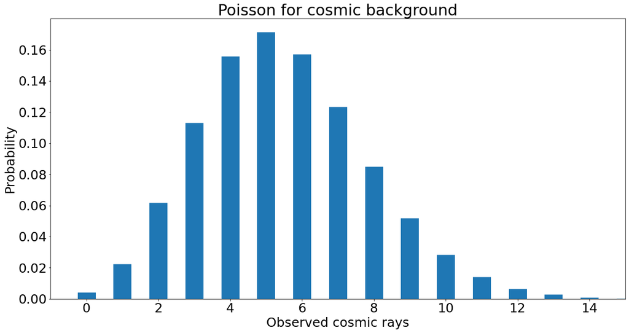

```python
# Problem 1
avg_cosmicRays = 5.5
avg_gammaRays = 7
x = np.arange(0,20)
dist = stats.poisson(avg_cosmicRays)
pmf = dist.pmf(x)

plt.vlines(x, 0, pmf,linewidth = 35)
plt.xlim(-1,15)
plt.ylim(0)
plt.xlabel("Observed cosmic rays")
plt.ylabel("Probability")
plt.title("Poisson for cosmic background")
```

The graph above shows the distribution of observed cosmic rays in 1 day, as we can observe the distribution looks poisson

```
(0.0, 40.0)
```

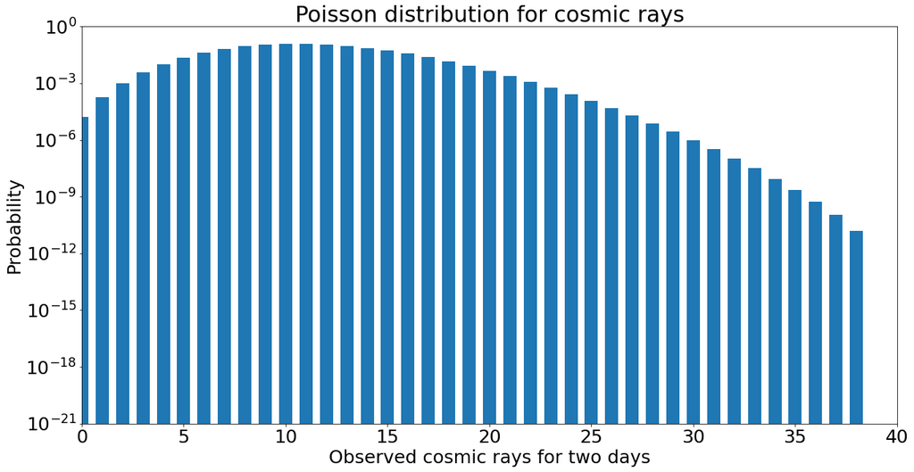

```python
pmf_2days = np.convolve(pmf,pmf)

plt.vlines(range(len(pmf_2days)), 0, pmf_2days,linewidth = 18)
plt.xlabel("Observed cosmic rays for two days")
plt.ylabel("Probability")
plt.title("Poisson distribution for cosmic rays")
plt.xlim(-1,15)
plt.ylim(0)
plt.yscale("log")
plt.ylim(10**(-21),1)
plt.xlim(0,40)
```

This is the graph for the distribution of sum of observed cosmic rays for two days, from by turing the graph into log scale we can see the distribution remains discrete and poisson.

Now we integrate for 5 days

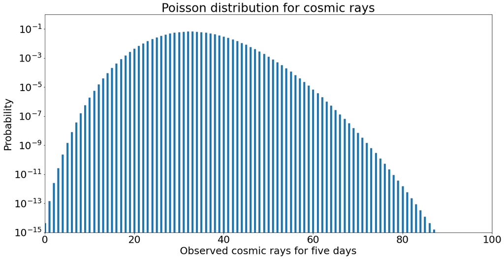

```python
days = 5
new_pmf = pmf
for i in range(days):
    new_pmf = np.convolve(new_pmf,pmf)

plt.vlines(range(len(new_pmf)), 0, new_pmf,linewidth = 5)
plt.yscale("log")
plt.xlim(0,100)
plt.ylim(10**(-15),1)
plt.xlabel("Observed cosmic rays for five days")
plt.ylabel("Probability")
plt.title("Poisson distribution for cosmic rays")
```

After intergrating for 5 days we can still tell the log scale distribution is still not a prefect parabola, the shape at the head(close to 0) of the distribution is much steeper than at the tail of the distribution, therefore the distribution remains possion,mathmatically it makes sense because convolving multiple poisson distributions gives a poisson distribution with a mean equal to the sum of the lambda of the distributions we are convolving.

Now we move on the problem 3, which follows the same steps for convolution but divide the axis by the days passed + 1.

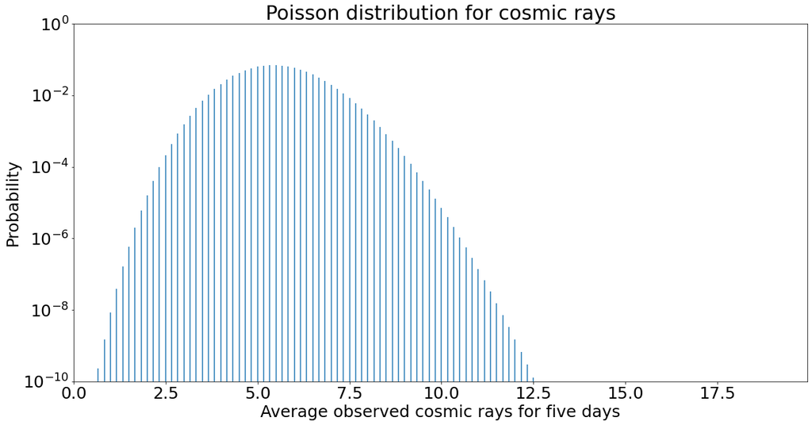

```python
pmfNew2 = pmf
for i in range(5):
    pmfNew2 = np.convolve(pmfNew2, pmf)
plt.vlines(np.arange(len(pmfNew2)) / 6, 0, pmfNew2)
plt.yscale("log")
plt.xlim(0)
plt.ylim(1e-10,1)
plt.xlabel("Average observed cosmic rays for five days")
plt.ylabel("Probability")
plt.title("Poisson distribution for cosmic rays")
```

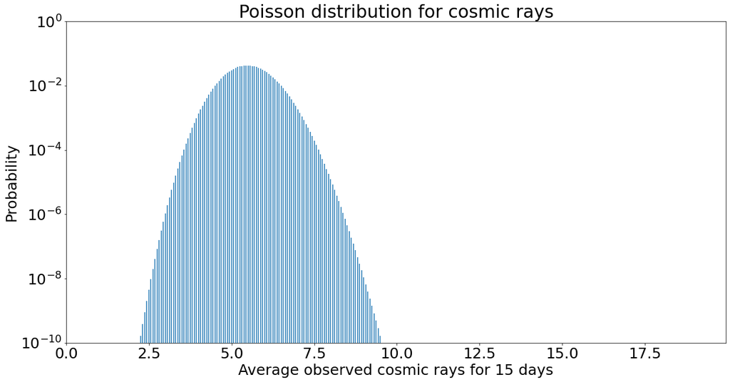

```python
pmfNew3 = pmf
for i in range(15):
    pmfNew3 = np.convolve(pmfNew3, pmf)
plt.vlines(np.arange(len(pmfNew3)) / 16, 0, pmfNew3)
plt.yscale("log")
plt.xlim(0)
plt.ylim(1e-10,1)
plt.xlabel("Average observed cosmic rays for 15 days")
plt.ylabel("Probability")
plt.title("Poisson distribution for cosmic rays")
```

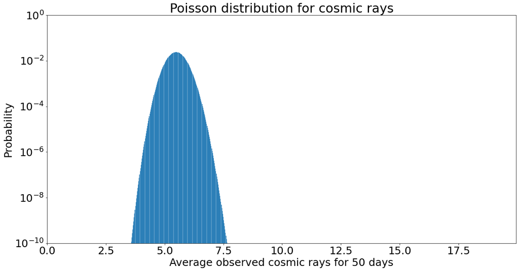

```python
pmfNew4 = pmf
for i in range(50):
    pmfNew4 = np.convolve(pmfNew4, pmf)
plt.vlines(np.arange(len(pmfNew4)) / 51, 0, pmfNew4)
plt.yscale("log")
plt.xlim(0)
plt.ylim(1e-10,1)
plt.xlabel("Average observed cosmic rays for 50 days")
plt.ylabel("Probability")
plt.title("Poisson distribution for cosmic rays")
```

As we average more days the shape of the distribution for average rays observed becomes narrower, and the shape is slowly turning from possion into gaussian because it becomes more like a downward parabola. This follows the central limit threorem as we are basically averaging multiple discrete distributions and as we go further the distribution gets closer to gaussian

Summed distribution mean = 15 * 5.5 = 82.5

```python
prob = 1-stats.poisson(82.5).cdf(105 - 1)
print(prob)
```

```
0.009576064715267174
```

```python
stats.norm.ppf(1 - prob)
```

```
2.34255658754234
```

The calculated sigma for the numbers I choose is about 2.34

# Problem 2

Pick a skewed continuous distribtuion, such as a Rayleigh, that describes your background over some observing interval.

A) Show how the distribution changes as you average over more observing intervals.

B) Discuss how the shape changes. Does it approach a Gaussian distribution? If yes, after how many intervals?

Let's work with a rayleigh distribution with a sigma of 1.

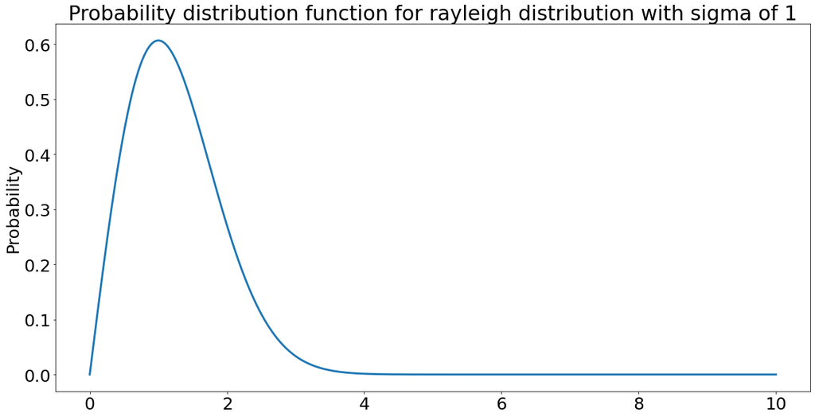

```python
dist = stats.rayleigh(scale=1)
x = np.linspace(0, 10, 800)
plt.plot(x, dist.pdf(x), linewidth=3)
plt.ylabel("Probability")
plt.title("Probability distribution function for rayleigh distribution with sigma of 1")
```

Integrate for 5 different numbers of days, with 10,20,30,40,50

```
(0.0, 10.0)
```

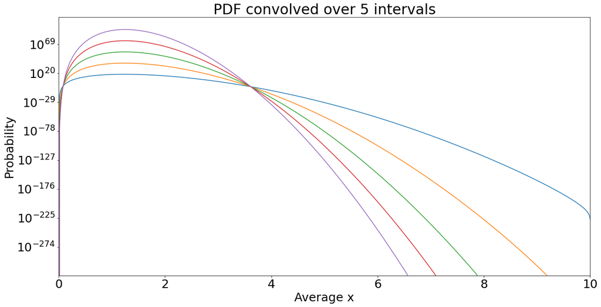

```python
pdf = dist.pdf(x)
new_pdf = pdf
for i in range(5):
    for j in range(10):
        new_pdf = np.convolve(new_pdf, pdf)
    plt.plot(np.linspace(0, 10, len(new_pdf)), new_pdf)
plt.yscale("log")
plt.title("PDF convolved over 5 intervals")
plt.xlabel("Average x")
plt.ylabel("Probability")
plt.xlim(0,10)
```

As we increase the number of days we convolve, the PDF becomes "taller" and narrower, however it's not exactly gaussian. Since we can still see the overall shape of the distribution in log scale is not exactly a downward parabola. Now we try a bigger number, say 200 days.

```
(1e-50, 1.3324834339666083e-08)
```

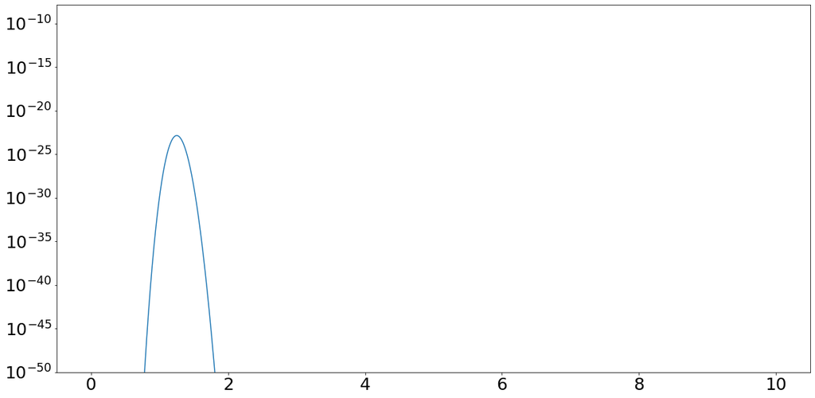

```python
days = 200
adjusted_pdf = pdf / 100  # in case the numbers become too big
for i in range(days):
    adjusted_pdf = np.convolve(adjusted_pdf, pdf/100)
plt.semilogy(np.linspace(0, 10, len(adjusted_pdf)), adjusted_pdf)
plt.ylim(1e-50)
```

After convolving 200 times, the log scaled distribution has a shape of a downward parabola, suggests that the distribution is getting closer to a gaussian distribution. And by dividing pdf by 100 should not effect the outcomes.

# Problem 3

## Version 1

You have an alert from LIGO that is also seen in with the X-ray/ultra-violet satellite SWIFT. SWIFT gives you a very precise location, so you take an image of that part of the sky. But because of SWIFT's accuracy, you know which pixel in your image to look for a counterpart in.

A) From looking at all the other pixels in your image, you can measure the width of the background Gaussian distribution X (pick something). Assuming you see a signal of strength Y (pick a floating-point number; optical CCDs are not sensitive enough to count photons so the readings are floating point brightnesses, not integer photons). Calculate the significance of your detection. Can you claim a discovery (traditionally 5-sigma or more)?

Assume we have a noise background with mean of 0 and the width of the background distribution be 2 brightness units. And we will plot the PDF of background noise for 1 pixel to start.

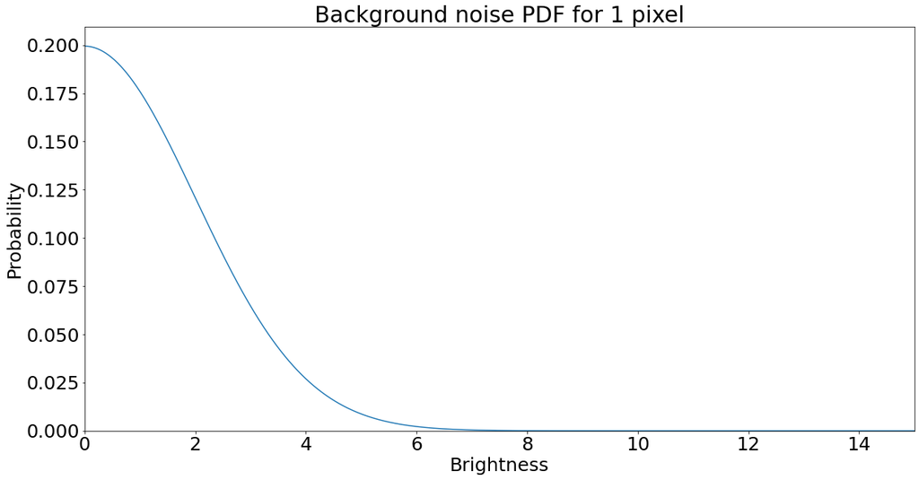

```python
dist = stats.norm(scale = 2)
x = np.linspace(0,15,800)
plt.plot(x,dist.pdf(x))
plt.xlim(0,15)
plt.ylim(0,None)
plt.xlabel("Brightness")
plt.ylabel("Probability")
plt.title("Background noise PDF for 1 pixel")
```

Assume we find a signal with 13.1 brightness unit, and we need to calculated the significance and see if it's big enough(larger than 5 sigma) in order to reject our null hypothesis. If we translate it into a statistical question: what's the probability that the signal-free background data of 1 pixel producing an outcome that's equally signal-like or more signal like than 13.1 units?

```python
prob = 1-dist.cdf(13.1)
prob
```

```
2.8768543103296906e-11
```

```python
stats.norm.ppf(1 - prob)
```

```
6.549999992902612
```

As we can see we are 6.55 sigmas away from the mean, which is larger than 5 sigmas, that means we can reject our null hypothesis and call it a discovery.

## Version 2

You have an alert from LIGO, but no associated detection from SWIFT. This could be because it is a black hole-black hole merger, a black hole-neutron star merger (neither seem to emit X-rays or UV light), or it could because SWIFT was indisposed at the time (wrong side of the earth in its orbit). Whatever the cause, you know what region of the sky to look in, but not which pixel.

B) If you have to look for a signal in 10k pixels, what is the probability distribution of your background? (Clearly state the statistical question, then turn that into math using your background distribution from part 1 of this problem.)

C) Taking your brightest candidate signal from the region (assume it has the same signal as in part 1), calculate the significance of your detection.

For this version of the problem we do it without the location data from SWIFT, if we search for a signal in 10k pixels, we combine the background distribution of all 10k pixels, and we do this by multiplying the background distribution for one pixel by 10k, and keep other parameters constant with the previous version.

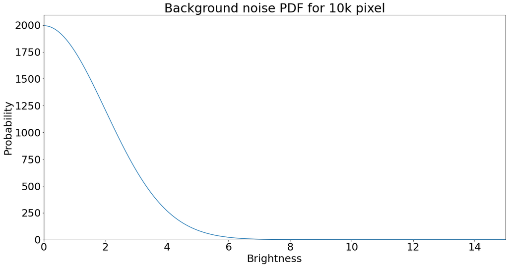

```python
dist = stats.norm(scale = 2)
x = np.linspace(0,15,800)
plt.plot(x,dist.pdf(x)*10000)
plt.xlim(0,15)
plt.ylim(0,None)
plt.xlabel("Brightness")
plt.ylabel("Probability")
plt.title("Background noise PDF for 10k pixel")
```

From the graph, looking at y-axis we can tell the height of the PDF increased by a factor of 10k. Let's pick the brightest candidate signal from the last question(brightness of 13.1) Translation to statistical question: what's the probability that the total signal-free background data of 10k pixels produces a measurement that's equally or more signal-like than 13.1? To find this out we integrate PDF of the total background distribution for the above distribution from 13.1 to infinity.

```python
prob = 10000 * (1-dist.cdf(13.1))
prob
```

```
2.8768543103296906e-07
```

Now we turn the probability into sigma

```python
stats.norm.ppf(1 - prob)
```

```
4.999305809853595
```

The sigma value we get is just smaller than 5, which means we are just not enough to reject the null hypothesis. We compensated for the look-elsewhere effect by multiplying the probability of getting a false signal from the background by 10k, which is the number of times we perform the trials.

# Problem 4

The statistical issue we were exploring in the previous problem is called a trials factor (sometimes known as a look-elsewhere effect). This is an important effect, as if you search through a million locations, you would expect to se ~1 one in a million event. However, it is also often over estimated how big an impact this makes on the sensitivity of a search. So in this part of the lab we are going to invert the problem.

Let us again assume we have a Gaussian background (same parameters as Problem 3).

A) Calculate the signal required for a 5-sigma detection in Version 1

B) Calculate the signal required for a 5-sigma detection in Version 2

C) Discuss how much brighter the signal must be for discoverey if you have a trials factor of 10k. Looking at your probability distributions, explain why the sensitivity penalty due to a trials factor is so low.

D) If you changed the trials factor significantly (orders of magnitude), how large is the effect on your 5-sigma sensitivity threshold?

Extra credit: If you had a different distribution shape (non-Gaussian), how would that affect the sensitivity penalty of many trials? Clearly explain.

To find the signal required for a 5-sigma dectection we now do the problem backwards. First we calculate the probability corresponding to 5 sigma

```python
prob = 1 - stats.norm.cdf(5)
prob
```

```
2.866515719235352e-07
```

Now the integrate the background distribution from prob to infinity which will give us the probability of 5 sigma. To do that we use the PPF function from our background distribution.

```python
threshold_1 = dist.ppf(1 - prob)
threshold_1
```

```
9.999999999940352
```

Therefore the 5 sigma detection will be at around 10. Now we do this again with a background noise distribution for 10k pixels

```python
prob5 = prob / 10000
threshold_2 = dist.ppf(1- prob5)
threshold_2
```

```
13.10107497378331
```

Comparing to the last threshold we find the 5 sigma detection increased to 13.1 from 10

```python
threshold_2/threshold_1
```

```
1.3101074973861455
```

By taking the ratio of these two thresholds we can conclude that our signal must be 31% brighter with a 10000 pixels in to consider it a discovery.

```python
(1-dist.cdf(threshold_2))/(1-dist.cdf(threshold_1))
```

```
0.00010000008423938031
```

From this number, we can see the chance is indeed 1 out of 10k. Why is the sensitivity penalty is so low? Because it's compensated by the large decrease in probability of seeing a signal at or above the slightly increased threshold.

Now let's find out what happens if we increase trials factor by a significant magnitude.

```python
trials = 10e7
newProb = prob / trials
threshold_3 = dist.ppf(1-newProb)
threshold_3
```

```
15.61761499383638
```

```python
threshold_3/threshold_1
```

```
1.5617614993929536
```

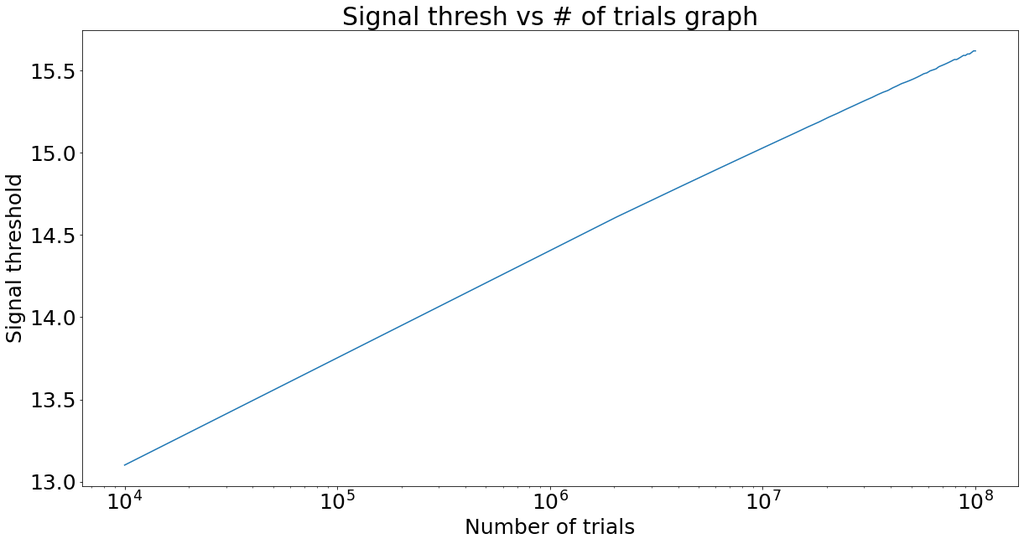

```python
n = np.linspace(10e3,10e7)
newProbs = prob / n
thresholds = dist.ppf(1-newProbs)
plt.semilogx(n,thresholds)
plt.xlabel("Number of trials")
plt.ylabel("Signal threshold")
plt.title("Signal thresh vs # of trials graph")
```

As we can see from the graph signal threshold and the number of trials has a positive logarithmical relationship.

# Extra credit

If you had a different distribution shape (non-Gaussian), how would that affect the sensitivity penalty of many trials? Clearly explain.

Say we have a rayleigh distribution, which is a non-gaussian distribution. And let's make it skew to the right with a sigma of 1

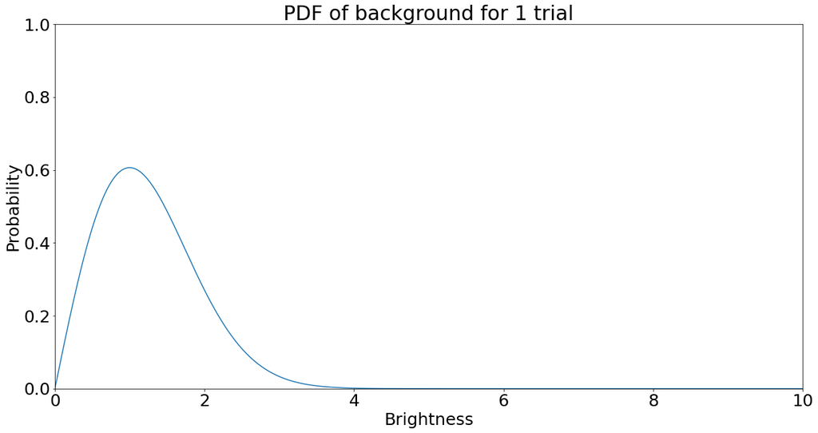

```python
dist = stats.rayleigh(scale = 1)
x = np.linspace(0,10,1000)
plt.plot(x,dist.pdf(x))
plt.xlim(0,10)
plt.ylim(0,1)
plt.xlabel("Brightness")
plt.ylabel("Probability")
plt.title("PDF of background for 1 trial")
```

```python
thresh_1 = dist.ppf(1-prob)
thresh_1
```

```
5.489079776034238
```

This is the signal threshold required for 5 sigma discovery

```python
thresh_2 = dist.ppf(1-prob/10000)
thresh_2
```

```
6.9678315024714506
```

This is the signal threshold required for 5 sigma over 10k trials.

```python
thresh_2/thresh_1
```

```
1.2693988403836944
```

As we can see this number only increased about 27% compared to gaussian 31%. Thus we can say that for rayleigh distributions the sensitivity penalty we found is smaller than gaussian distribution.